# Cardio Good Fitness Project

#### *To understand the distribution better, we will create additional columns to plot the distribution of data*

- Added 2 new feature from Age

> *Category* - Teens, Youngsters, Above30s and Middleaged

> *AgeRange* - 14-20 , 20-30, 30-40 & 40-60
- Added 1 new categorial feature based on the income

> *IncomeRange* - Low Income, Middle income, Moderate income and High income

```python
bins = [14,20,30,40,60]
labels =["Teens","Youngsters","Above30s","Middleaged"]
data['AgeRange'] = pd.cut(data['Age'], bins)
data['Category'] = pd.cut(data['Age'], bins,labels=labels)

bins_income = [29000, 35000, 60000, 85000,105000]
labels_income = ['Low Income','Middle income','Moderate income', 'High income']
data['IncomeRange'] = pd.cut(data['Income'],bins_income,labels = labels_income)
```

```python
data.head()
```

|  | Product | Age | Gender | Education | MaritalStatus | Usage | Fitness | Income | Miles | AgeRange | Category | IncomeRange |
| --- | --- | --- | --- | --- | --- | --- | --- | --- | --- | --- | --- | --- |
| 0 | TM195 | 18 | Male | 14 | Single | 3 | 4 | 29562 | 112 | (14, 20] | Teens | Low Income |
| 1 | TM195 | 19 | Male | 15 | Single | 2 | 3 | 31836 | 75 | (14, 20] | Teens | Low Income |
| 2 | TM195 | 19 | Female | 14 | Partnered | 4 | 3 | 30699 | 66 | (14, 20] | Teens | Low Income |
| 3 | TM195 | 19 | Male | 12 | Single | 3 | 3 | 32973 | 85 | (14, 20] | Teens | Low Income |
| 4 | TM195 | 20 | Male | 13 | Partnered | 4 | 2 | 35247 | 47 | (14, 20] | Teens | Middle income |

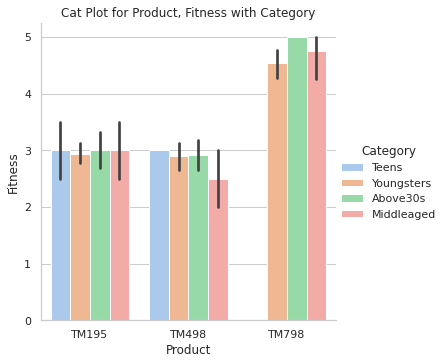

```python
sns.catplot(data=data, x="Product", y="Fitness", hue="Category", kind='bar', palette='pastel').set(title='Cat Plot for Product, Fitness with Category')
```

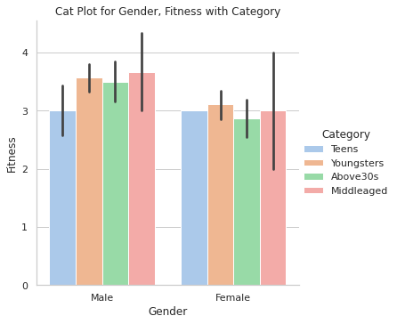

```python
sns.catplot(data=data, x="Gender", y="Fitness", hue="Category", kind='bar', palette='pastel').set(title='Cat Plot for Gender, Fitness with Category')
```

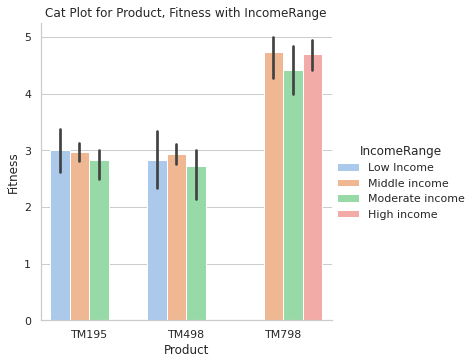

```python
sns.catplot(data=data, x="Product", y="Fitness", hue="IncomeRange", kind='bar', palette='pastel').set(title='Cat Plot for Product, Fitness with IncomeRange')
```

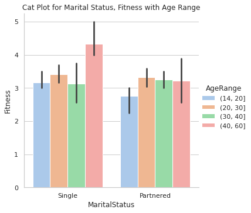

```python
sns.catplot(data=data, x="MaritalStatus", y="Fitness", hue="AgeRange", kind='bar', palette='pastel').set(title='Cat Plot for Marital Status, Fitness with Age Range')
```

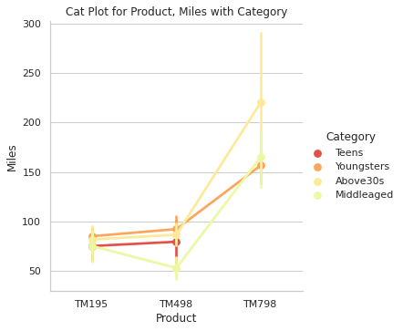

```python
sns.catplot(data=data, x='Product', y='Miles', hue='Category', kind='point').set(title='Cat Plot for Product, Miles with Category')
```

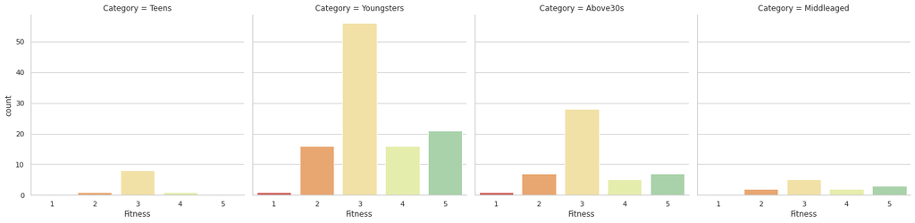

```python
plt.figure(figsize=(20,7))
sns.catplot(x="Fitness", data = data, col="Category", kind = "count" )
```

```
[Text(0.5, 1.0, 'Scatter Plot for Age, Miles with Product')]
```

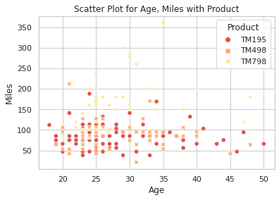

```python
sns.scatterplot(data=data, x='Age', y='Miles', hue='Product', style='Product').set(title='Scatter Plot for Age, Miles with Product')
```

```
[Text(0.5, 1.0, 'Strip Plot for Age, Fitness with Product')]
```

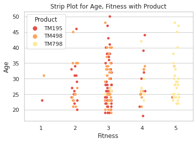

```python
sns.stripplot(data=data, x='Fitness', y='Age', hue="Product", jitter=True).set(title='Strip Plot for Age, Fitness with Product')
```

```
[Text(0.5, 1.0, 'Strip Plot for Fitness, Education with Product')]
```

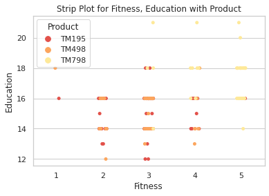

```python
sns.stripplot(data=data, x='Fitness', y='Education', hue="Product", jitter=True).set(title='Strip Plot for Fitness, Education with Product')
```

## *Multi-Variate Analysis*

#### **Correlation Matrix**

```
                Age  Education     Usage   Fitness    Income     Miles
Age        1.000000   0.280496  0.015064  0.061105  0.513414  0.036618
Education  0.280496   1.000000  0.395155  0.410581  0.625827  0.307284
Usage      0.015064   0.395155  1.000000  0.668606  0.519537  0.759130
Fitness    0.061105   0.410581  0.668606  1.000000  0.535005  0.785702
Income     0.513414   0.625827  0.519537  0.535005  1.000000  0.543473
Miles      0.036618   0.307284  0.759130  0.785702  0.543473  1.000000
Usage      Age          0.015064
Age        Usage        0.015064
           Miles        0.036618
Miles      Age          0.036618
Age        Fitness      0.061105
Fitness    Age          0.061105
Age        Education    0.280496
Education  Age          0.280496
Miles      Education    0.307284
Education  Miles        0.307284
           Usage        0.395155
Usage      Education    0.395155
Education  Fitness      0.410581
Fitness    Education    0.410581
Age        Income       0.513414
Income     Age          0.513414
           Usage        0.519537
Usage      Income       0.519537
Income     Fitness      0.535005
Fitness    Income       0.535005
Income     Miles        0.543473
Miles      Income       0.543473
Education  Income       0.625827
Income     Education    0.625827
Usage      Fitness      0.668606
Fitness    Usage        0.668606
Usage      Miles        0.759130
Miles      Usage        0.759130
           Fitness      0.785702
Fitness    Miles        0.785702
Age        Age          1.000000
Fitness    Fitness      1.000000
Usage      Usage        1.000000
Education  Education    1.000000
Income     Income       1.000000
Miles      Miles        1.000000
dtype: float64
```

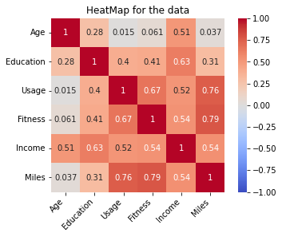

```python
corr = data.corr()

print(corr)

s = corr.unstack()
sortedval = s.sort_values(kind="quicksort")

print(sortedval)

ax = sns.heatmap(
    corr,
    vmin=-1, vmax=1, center=0, annot=True,
    cmap=sns.color_palette("coolwarm", as_cmap=True),
    square=True
)
ax.set_xticklabels(
    ax.get_xticklabels(),
    rotation=45,
    horizontalalignment='right'
)
ax.set_title('HeatMap for the data')
```

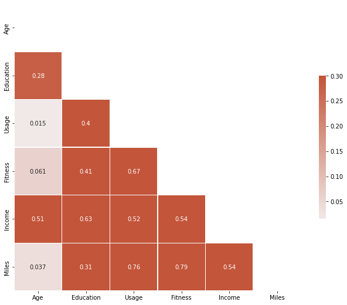

```python
# Generate a mask for the upper triangle
mask = np.triu(np.ones_like(corr, dtype=bool))

# Set up the matplotlib figure
f, ax = plt.subplots(figsize=(11, 9))

# Generate a custom diverging colormap
cmap = sns.diverging_palette(230, 20, as_cmap=True)

# Draw the heatmap with the mask and correct aspect ratio
sns.heatmap(corr, mask=mask, cmap=cmap, vmax=.3, center=0,annot=True,
            square=True, linewidths=.5, cbar_kws={"shrink": .5})
```

*Observations*

- From the Correlation Matrix, it is found that the data is positively correlated
- Usage and Miles are highly Correlated meaning More the usage of the treadmill means the miles covered per week will be high
- Fitnes and Usage are positively correlated meaning More the usage of the treadmill in a week implies a high fitness score for the customer

```python
data.cov()
```

|  | Age | Education | Usage | Fitness | Income | Miles |
| --- | --- | --- | --- | --- | --- | --- |
| Age | 48.212166 | 3.149410 | 0.113470 | 0.406828 | 5.884446e+04 | 13.186530 |
| Education | 3.149410 | 2.614867 | 0.693172 | 0.636623 | 1.670472e+04 | 25.770795 |
| Usage | 0.113470 | 0.693172 | 1.176785 | 0.695469 | 9.303043e+03 | 42.709808 |
| Fitness | 0.406828 | 0.636623 | 0.695469 | 0.919429 | 8.467925e+03 | 39.073246 |
| Income | 58844.463439 | 16704.717815 | 9303.042582 | 8467.925388 | 2.724706e+08 | 465265.361887 |
| Miles | 13.186530 | 25.770795 | 42.709808 | 39.073246 | 4.652654e+05 | 2689.833489 |

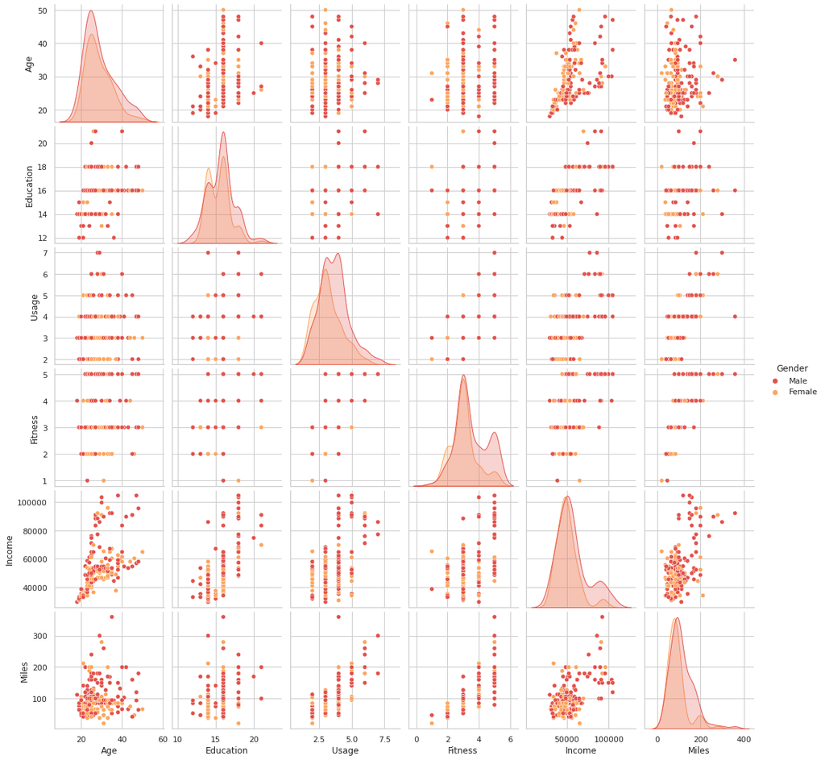

```python
sns.set_theme(style='whitegrid', palette="Spectral")
sns.pairplot(data, hue='Gender')
```

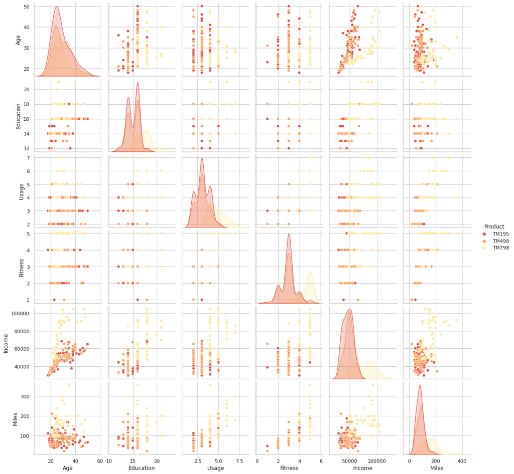

```python
sns.set_theme(style='whitegrid', palette="Spectral")
sns.pairplot(data, hue='Product')
```

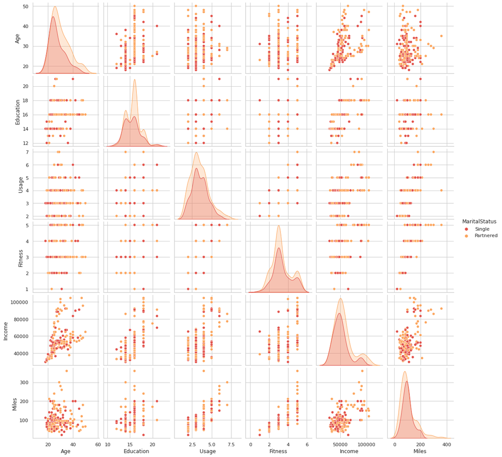

```python
sns.set_theme(style='whitegrid', palette="Spectral")
sns.pairplot(data, hue='MaritalStatus')
```

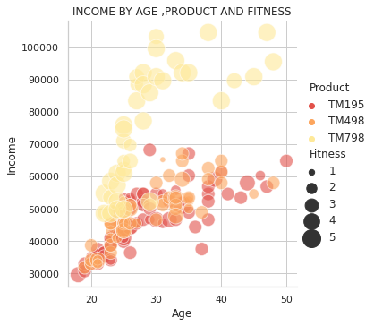

```python
sns.relplot(x='Age', y='Income',data=data, hue = "Product", size = "Fitness", alpha = 0.6, sizes = (40,400)).set(title='INCOME BY AGE ,PRODUCT AND FITNESS');
```

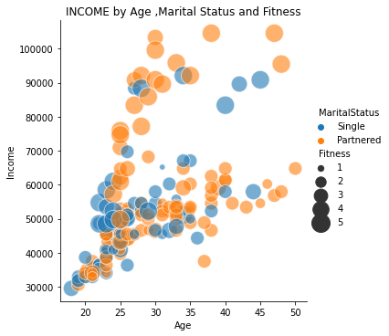

```python
sns.relplot(x='Age', y='Income',data=data, hue = "MaritalStatus", size = "Fitness", alpha = 0.6, sizes = (40,400)).set(title='INCOME by Age ,Marital Status and Fitness');
```

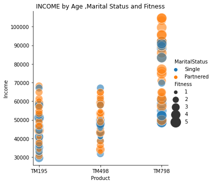

```python
sns.relplot(x='Product', y='Income',data=data, hue = "MaritalStatus", size = "Fitness", alpha = 0.6, sizes = (40,400)).set(title='INCOME by Age ,Marital Status and Fitness');
```

*Observations*

- Products TM195 and TM498 are bought by people with lower than 70K as income and age is concentrated more in range of 23-35
- Product TM798 is mainly bought by people with higher than 70K income. Majority of people who buys the TM798 are generally very active and fit
- Partnered customers are using TM798 and ran more miles than single customers comparatively
- The income of Single customers are less than 70K only with few exceptions

## **Conclusions and Recommendations**

#### *Insights on Products used by Customers*

**TM195**

- The Most sold product and ageneral purpose treadmill for all the user age groups.It can be marketed as a base product for the customers who get in to fitness regime in the beginner level.This model suits for the younger Population and customers with a limited usage of 3 or 4 times in a week

**TM498**

- The TM498 model is similar to TM195 and has the same characteristics. Both Models can go together for the users who fall in the average usage category. Also, this model is suitable for the users with an income of less than 70K

**TM798**

- TM798 is the high end model with great specification which generates interest to the fitness freaks. TM798 is mostly the premium treadmill product of the company. Customers using this model are highly fit as they posses a good fitness score and covered more miles per week than any other customers using other models. The customers are highly educated and belonging to the high income group. Primarily, this model is bought by the Male customers.

#### **Business Recommendations**

- The offerings from the retail store caters to the needs of the customers ranging from Low to high income groups spanning across ages and with different fitness interests
- The models TM195 and TM498 primarily caters to the beginners and an affordable product to cater the moderate usage needs
- To increase the sales of the premium product TM798, the store focusses on attracting the teens, younger community to buy it as they are not using it.
- Brand the TM 798 as a model used by Athletes to promote the sales among the teens.
- Recommendations for the higher income group with good education levels is to use the premium model TM798
- The campaign to be created for the different age groups addressing the needs so that all the 3 models can be used by different age groups
- Partnered Customers are more than the Single customers. Using right advertisement, more families/partners can be made aware on the fitness needs and the usage of the Treadmills
- Singles above 40 years can be recommended with the higher end product(TM798) as they wish to run more miles and therefore the usage would be higher.
- Create an exclusive offering for the income group between 50-70K with EMI plans so that they can be recommended to buy the premium product of the company.
- TM798 to be recommended for Partnered males with a higher income
- Investigate on why the female customers are no prefering the Model TM798 and take corrective actions such as Offers, Incentives, special campaigns to promote awareness on products etc. to increase the sales among females
- Considering above observations, We can attract customers to upgrade from their existing treadmill and switch to TM798 ,highlighting extra features this Treadmill provides.